# Homework Three

April Wright

10/15/2021

# Plotting and choices

## 10 points, due Sept. 16 at 5 PM

```
download.file(url = "https://raw.githubusercontent.com/BiologicalDataAnalysis2019/2022/main/vignettes/homework_3.Rmd", destfile = "/cloud/project/homeworks/homework_3.Rmd")
```

0. Read in the surveys.csv dataset. Remove NAs from the datasets.

```r
setwd("C:/Users/basan/Desktop/Fall 2022/Biological_Data_Analysis/")
data <- read.csv("data/surveys.csv")
data <- na.omit(data)
```

1. In this homework, we’re going to explore how different ways of visualizing the same data. First, take a look at `geom_col()`. Group the surveys data by the species_id column and count how many of each species there are. Use this count data to make a bar plot of the counts per species.

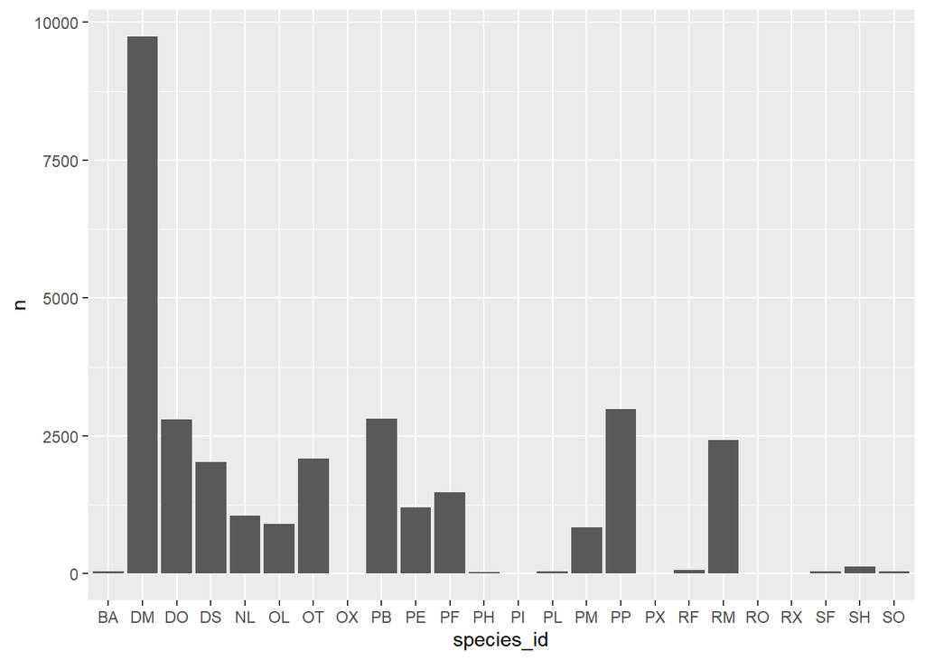

```r
library(tidyverse, ggplot2)
species_group <- data %>%
  count(species_id)
ggplot(data=species_group, mapping = aes(species_id, n)) + geom_col()
```

2. Take a look at the argument `fct_reorder`. It reorders variables on one or both axes. Try using this to plot the species in order from most to least members.

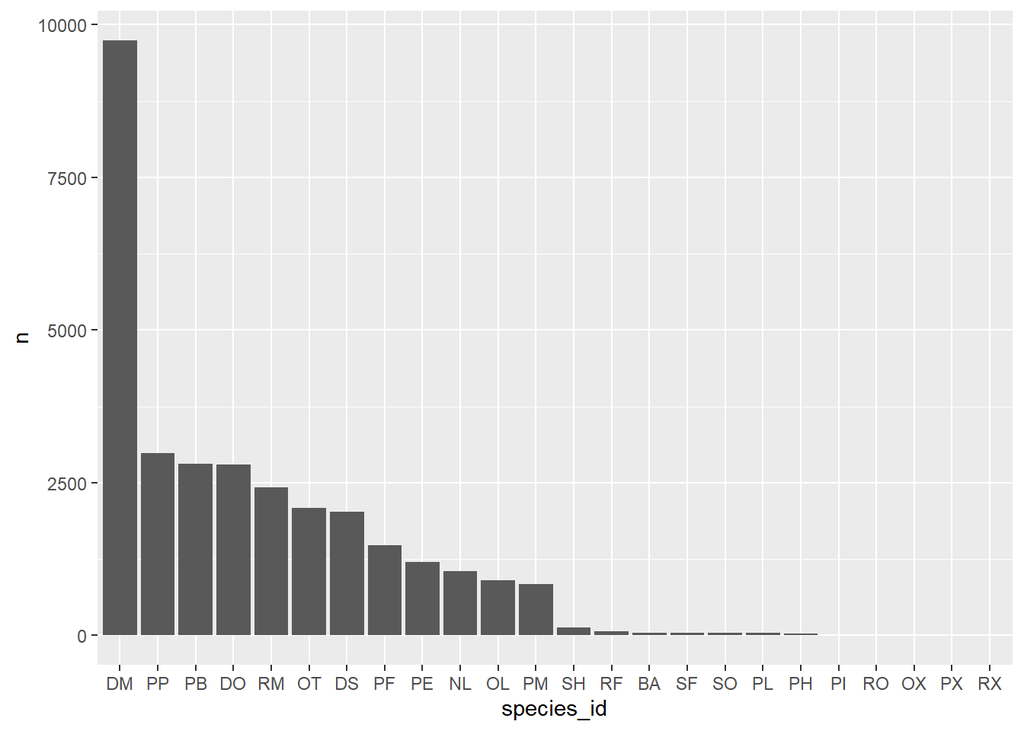

```r
library(forcats)
species_group %>%
  mutate(species_id=fct_reorder(species_id, n, .desc = TRUE)) %>%
  ggplot(aes(x=species_id, y=n)) +
  geom_col()
```

3. What we canonically think of as a bar plot can also be made in R. These can have some interesting properties, such as being able to fill in bars by other aesthetics. Using the surveys dataset, try to plot the number of members of each species, with the bar filled in by sex.

```r
ggplot(data, mapping = aes(x=species_id, fill=sex)) +
  geom_bar()
```

[output not shown]

4. `geom_bar` accepts various arguments. Try `postion="dodge"` or `position="stack"`. How does this change the plot and how you interpret it?

```r
When the argument 'dodge' is used, the bars for male and female appear side by side and when 'stack' is used the female count appears on top of the male count bar. I like the dodge option because, it gives the count for both males and females which can easily be seen/counted. But it depends on your need, if you also need the total number, the stack option would be easier.
```

5. Even a simple histogram can lead to different interpretations. Make a histogram of hindfoot_lengths in the surveys dataset. Try choosing different binwidths. How does a high binwidth (like 100) this change your interpretation of how the data are distributed?

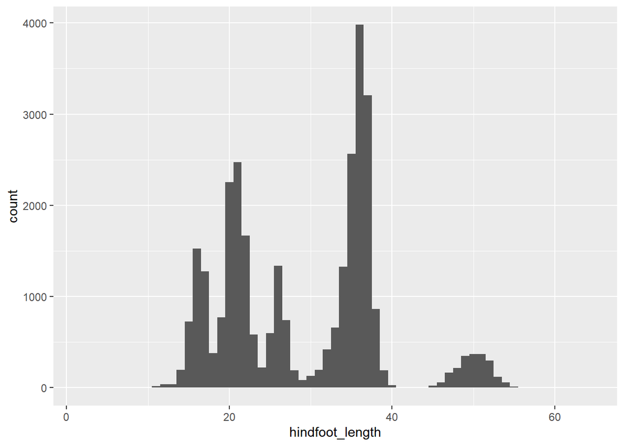

```r
ggplot(data, aes(x=hindfoot_length)) + geom_histogram(binwidth = 1)
```

[figure not shown]

```
`binwidth` controls the width of each bin along the X-axis of the histogram. When a low value is used, we can see the distribution of the data pretty nicely than while using a high value. When a higher binwidth is used, it might lead to a different (and possibly wrong) interpretation of the data.
```

```r
ggplot(data, aes(x=hindfoot_length)) + geom_histogram(binwidth = 100)
```

6. Next, let’s take a look at density plots. First, look at the help for `geom_density`. Density plots are like a smoothed histogram, mostly used for continuous data. But how density is calculated is done using what is called a kernel. To get a sense for what this means, try different kernel types. Some common ones are “triangular”, “rectangular”, and “gaussian.” Try them out, and put the one you think best represents the data in the answer below.

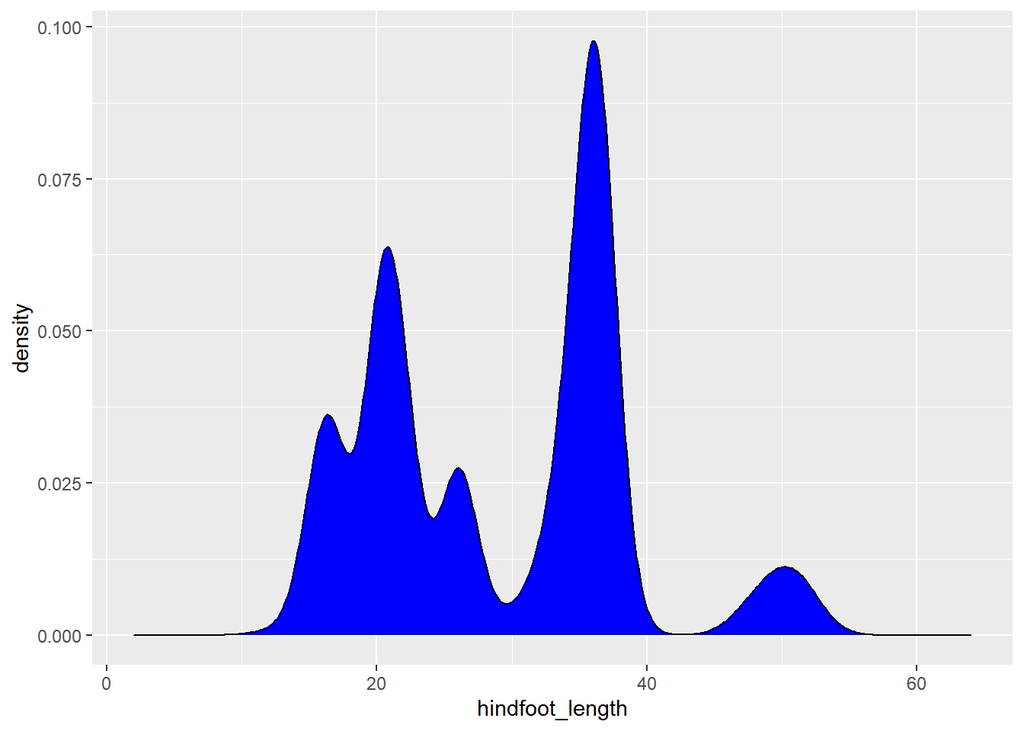

```r
ggplot(data, aes(hindfoot_length)) +
  geom_density(fill = "blue", binwidth = 10, kernel ="gaussian")
```

## Graduate Students:

A common set of journal figure requirements several of you submitted include the following:

- PDF or PNG
- At least 300 DPI
- One column (80 mm) or two column (160mm) wide.

```r
I am using the requirements from the list above and the plots are saved in "homeworks/Khakurel_Plots/output"
```

For each of your plots on the above homework, save figures meeting all requirements in your lastname_directory in a directory called `output.`

As a longer-term goal, you each picked a few figures. See if you can find the data that the authors used to make the figures. One of the best ways to learn to make good figures in your field is to copy from what’s already published.

```
For these answers, I am using preprint from Barido-Sottani et.al. 2022 (https://doi.org/10.1101/2022.07.07.499091).
Specifically, Figure 2 or 3.
```

[figure not shown]

What data did the author’s use?

```
The author has used data obtained from comparisons of phylogenies. It could include small values ranging from 0 to 1.
```

Is the data you’re using for class similar to these data?

```
It probably will be similar to the data the authors had.
```

Could you process your data to be similar to these data?

```
I would be able to process the data and create similar plots from my data.
```

Finally, in the final project in this class, you’ll need to produce an R package with five functions:

- One or two for data cleaning and/or data manipulation
- One or two for a statistical test (ANOVA, linear models, other specialized analyses)
- One or two for plotting
- One of your choice for funsies.

In next week’s homework, you’ll be expected to pick and write one. So start thinking about one now.